# Exercise 4

wenbo

## Conceptual

### Q2

$p_k(x)$ is the posterior probability that an observation X=x belongs to the the kth class and it is:
$$p_k(x)=\frac{\pi_k\frac{1}{\sqrt{2\pi}\delta}exp(-\frac{1}{2\delta^2}(x-\mu_k)^2)}{\sum_{l=1}^K \pi_l \frac{1}{\sqrt{2\pi}}exp(-\frac{1}{2\delta^2}(x-\mu_l)^2)}$$

Then we take the log for both sides:

*Notice that the denominator is a constant for the observations in each class, so we set it $C$.

$$\log p_k(x)=\frac{\log \pi_k+\log\frac{1}{\sqrt{2\pi}\delta}-\frac{x^2}{2\delta^2}-\frac{\mu_k^2}{2\delta^2}+\frac{x\mu_k}{\delta^2}}{C}$$
Here we can see the second term and the third term is the same for all classes, so maximizing $\delta_k(x)$ in (4.13) is equivalent to maximize $\log p_k(x)$. Since log is an increasing function when it is positive, $p_k(x)$ in (4.12) is equivalent to (4.13).

### Q3

We can write posterior probability of the k-th class:
$$p_k(x)=\frac{\pi_k\frac{1}{\sqrt{2\pi}\delta_k}exp(-\frac{1}{2\delta^2}(x-\mu_k)^2)}{\sum_{l=1}^K \pi_l \frac{1}{\sqrt{2\pi}}exp(-\frac{1}{2\delta_k^2}(x-\mu_l)^2)}$$
Then we can take the log, which is similar to (3) and the denominator is still a constant C.
$$\log p_k(x)=\frac{\log \pi_k+\log\frac{1}{\sqrt{2\pi}\delta_k}-\frac{x^2}{2\delta_k^2}-\frac{\mu_k^2}{2\delta^2}+\frac{x\mu_k}{\delta^2}}{C}$$
Notice the third term and it is a quadratic function of x. So Bayes’s classfier not linear.

### Q4

#### (a)

On average, 1/10 will be used to make the prediction because observations are uniformly distribution.

#### (b)

On average, when p=2, $\frac{1}{10}*\frac{1}{10}=\frac{1}{100}$

#### (c)

On average, when p=100, $(\frac{1}{10})^{100}$

#### (d)

Suppose on each dimension, we uniformly divided range of [0, 1] to 100 bins. If we want to find the nearest points within 10% of range of X1, X2 thourgh X100 (given p=100), then we need 10100 of data to cover the range. Therefore, as the p increases, the number of observations needed grows exponentially.

#### (e)

When there are a large number of dimensions, the percentage of observations that can be used to predict with KNN becomes very small. This means that for a set sample size, more features leads to fewer neighbors.

#### (f)

*p=2: side length is $(0.1)^\frac{1}{2}$

*p=n: side length is $(0.1)^\frac{1}{n}$

### Q5

#### (a)

QDA better on training set, LDA better on test set.

#### (b)

QDA better on both sets.

#### (c)

As sample size increases, test prediction aacuracy of QDA is improved relative to LDA.

Reason: QDA is more flexible than LDA, so when data size incrases, it can fit better.

#### (d)

False. QDA tend to be overfitting when the decision boundary is just linear.

### Q6

#### (a)

```r
exp(-6+0.05*40+1*3.5)/(1+exp(-6+0.05*40+1*3.5))
```

```
## [1] 0.3775407
```

The probability for this student to get A is nearly 0.38.

#### (b)

$$\frac{\log(\frac{p(x)}{1-p(x)}e^{-\beta_0-\beta_2X_2})}{\beta_1}=X_1$$

```r
log(0.5/0.5*exp(6-3.5))/0.05
```

```
## [1] 50
```

50 hours are needed.

### Q7

There are two classes of response value. Here we can use Bayes’ therorem:
$$Pr(Y=Yes|X=x)=\frac{\pi_1 f_1(x)}{\sum_{l=1}^2\pi_l f_l(x)}$$
Here $\pi_1=0.8,\pi_2=0.2$,f_1(x) is the density function of a normal random variable with mean 10 and variance 36 and f_2(x) is the density function of a normal random variable with mean 0 and variance 36.

```r
(0.8*dnorm(4,mean=10,sd=6))/(0.8*dnorm(4,mean=10,sd=6)+0.2*dnorm(4,mean=0,sd=6))
```

```
## [1] 0.7518525
```

### Q8

### Q9

#### (a)

we want to solve p(x)
$$p(x)/(1-p(x))=0.37$$
so p(x) is about 0.27. It means in average, 27% people with odds 0.37 will in fact default.

#### (b)

The odds is $0.16/(1-0.16)\approx0.19$

## Applied

### Q10

#### (a)

```r
library(ISLR)
head(Weekly)
```

```
##   Year   Lag1   Lag2   Lag3   Lag4   Lag5    Volume  Today Direction
## 1 1990  0.816  1.572 -3.936 -0.229 -3.484 0.1549760 -0.270      Down
## 2 1990 -0.270  0.816  1.572 -3.936 -0.229 0.1485740 -2.576      Down
## 3 1990 -2.576 -0.270  0.816  1.572 -3.936 0.1598375  3.514        Up
## 4 1990  3.514 -2.576 -0.270  0.816  1.572 0.1616300  0.712        Up
## 5 1990  0.712  3.514 -2.576 -0.270  0.816 0.1537280  1.178        Up
## 6 1990  1.178  0.712  3.514 -2.576 -0.270 0.1544440 -1.372      Down
```

```r
summary(Weekly)
```

```
##       Year           Lag1               Lag2               Lag3
##  Min.   :1990   Min.   :-18.1950   Min.   :-18.1950   Min.   :-18.1950
##  1st Qu.:1995   1st Qu.: -1.1540   1st Qu.: -1.1540   1st Qu.: -1.1580
##  Median :2000   Median :  0.2410   Median :  0.2410   Median :  0.2410
##  Mean   :2000   Mean   :  0.1506   Mean   :  0.1511   Mean   :  0.1472
##  3rd Qu.:2005   3rd Qu.:  1.4050   3rd Qu.:  1.4090   3rd Qu.:  1.4090
##  Max.   :2010   Max.   : 12.0260   Max.   : 12.0260   Max.   : 12.0260
##       Lag4               Lag5              Volume
##  Min.   :-18.1950   Min.   :-18.1950   Min.   :0.08747
##  1st Qu.: -1.1580   1st Qu.: -1.1660   1st Qu.:0.33202
##  Median :  0.2380   Median :  0.2340   Median :1.00268
##  Mean   :  0.1458   Mean   :  0.1399   Mean   :1.57462
##  3rd Qu.:  1.4090   3rd Qu.:  1.4050   3rd Qu.:2.05373
##  Max.   : 12.0260   Max.   : 12.0260   Max.   :9.32821
##      Today          Direction
##  Min.   :-18.1950   Down:484
##  1st Qu.: -1.1540   Up  :605
##  Median :  0.2410
##  Mean   :  0.1499
##  3rd Qu.:  1.4050
##  Max.   : 12.0260
```

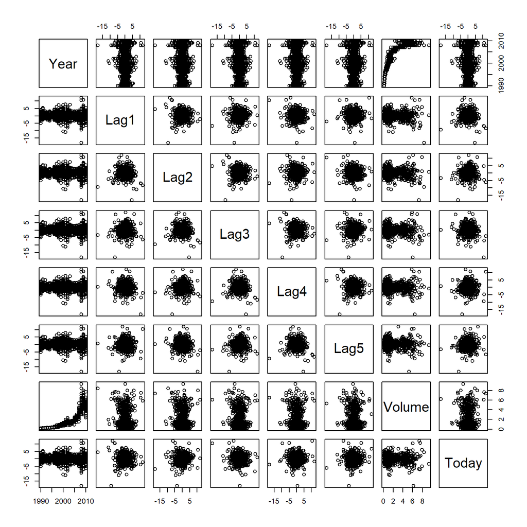

```r
pairs(~Year+Lag1+Lag2+Lag3+Lag4+Lag5+Volume+Today,Weekly)
```

#### (b)

```r
glm.fit=glm(Direction~Lag1+Lag2+Lag3+Lag4+Lag5+Volume,data=Weekly,family=binomial)
summary(glm.fit)
```

```
##
## Call:
## glm(formula = Direction ~ Lag1 + Lag2 + Lag3 + Lag4 + Lag5 +
##     Volume, family = binomial, data = Weekly)
##
## Deviance Residuals:
##     Min       1Q   Median       3Q      Max
## -1.6949  -1.2565   0.9913   1.0849   1.4579
##
## Coefficients:
##             Estimate Std. Error z value Pr(>|z|)
## (Intercept)  0.26686    0.08593   3.106   0.0019 **
## Lag1        -0.04127    0.02641  -1.563   0.1181
## Lag2         0.05844    0.02686   2.175   0.0296 *
## Lag3        -0.01606    0.02666  -0.602   0.5469
## Lag4        -0.02779    0.02646  -1.050   0.2937
## Lag5        -0.01447    0.02638  -0.549   0.5833
## Volume      -0.02274    0.03690  -0.616   0.5377
## ---
## Signif. codes:  0 '***' 0.001 '**' 0.01 '*' 0.05 '.' 0.1 ' ' 1
##
## (Dispersion parameter for binomial family taken to be 1)
##
##     Null deviance: 1496.2  on 1088  degrees of freedom
## Residual deviance: 1486.4  on 1082  degrees of freedom
## AIC: 1500.4
##
## Number of Fisher Scoring iterations: 4
```

Lag2 appears to be statistically important.

#### (c)

```r
glm.prob=predict(glm.fit,type='response')
glm.pred=rep('Down',1089)
glm.pred[glm.prob>0.5]='Up'
table(glm.pred,Weekly[,"Direction"])
```

```
##
## glm.pred Down  Up
##     Down   54  48
##     Up    430 557
```

```r
# complete.cases(Weekly[,"Direction"])
```

Overfall fraction of correct predictions is $\frac{54+557}{54+48+430+557} \approx0.56$

The error rate of falsely predict down days to up is $\frac{48}{48+54} \approx0.47$

The error rate of falsely predict up days to up is $\frac{430}{430+557} \approx0.44$

#### (d)

```r
library(dplyr)
train=filter(Weekly,Year>=1990&Year<=2008)
test=filter(Weekly,Year>2008)
glm.fit1=glm(Direction~Lag2,data=train,family=binomial)
glm.prob1=predict(glm.fit1,test,type='response')
glm.pred1=rep('Down',104)
glm.pred1[glm.prob1>0.5]='Up'
table(glm.pred1,test[,"Direction"])
```

```
##
## glm.pred1 Down Up
##      Down    9  5
##      Up     34 56
```

```r
mean(glm.pred1==test[,"Direction"])
```

```
## [1] 0.625
```

overall fraction of correct predictions for the held out data is $0.625$.

#### (e)

```r
library(dplyr)
library(MASS)
lda.fit=lda(Direction~Lag2,train)
lda.pred=predict(lda.fit,test)
lda.class=lda.pred$class
table(lda.class,test[,"Direction"])
```

```
##
## lda.class Down Up
##      Down    9  5
##      Up     34 56
```

```r
mean(lda.class==test[,"Direction"])
```

```
## [1] 0.625
```

overall fraction of correct predictions for the held out data is $65/104\approx0.625$.

#### (f)

```r
qda.fit=qda(Direction~Lag2,train)
qda.pred=predict(qda.fit,test)
qda.class=qda.pred$class
table(qda.class,test[,"Direction"])
```

```
##
## qda.class Down Up
##      Down    0  0
##      Up     43 61
```

```r
mean(qda.class==test[,"Direction"])
```

```
## [1] 0.5865385
```

overall fraction of correct predictions for the held out data is $61/104\approx0.59$.

#### (g)

```r
library(class)
train.x=as.matrix(train$Lag2)
test.x=as.matrix(test$Lag2)
train.y=train$Direction
set.seed(1)
knn.pred=knn(train.x,test.x,train.y,k=1)
table(knn.pred,test$Direction)
```

```
##
## knn.pred Down Up
##     Down   21 30
##     Up     22 31
```

```r
mean(knn.pred==test[,"Direction"])
```

```
## [1] 0.5
```

overall fraction of correct predictions for the held out data is $0.5$.

#### (h)

Logistic regression and LDA provide the best results.

#### (i)

Here we conduct experiments with KNN.

```r
k=c(1,3,5,10,15,20,30)
rate=rep(0,7)
a=1
for(i in k){
  knn.pred=knn(train.x,test.x,train.y,k=i)
  table(knn.pred,test$Direction)
  rate[a]=mean(knn.pred==test[,"Direction"])
  a=a+1
}
rate
```

```
## [1] 0.5000000 0.5576923 0.5384615 0.5769231 0.5865385 0.5769231 0.5576923
```

When k value is between 10 to 30, we can most likely obtain the best results.

### Q11

#### (a)

```r
med=median(Auto$mpg)
mpg01=rep(0,dim(Auto)[1])
mpg01[Auto$mpg>=med]=1
new_Auto=data.frame(Auto,mpg01)
```

#### (b)

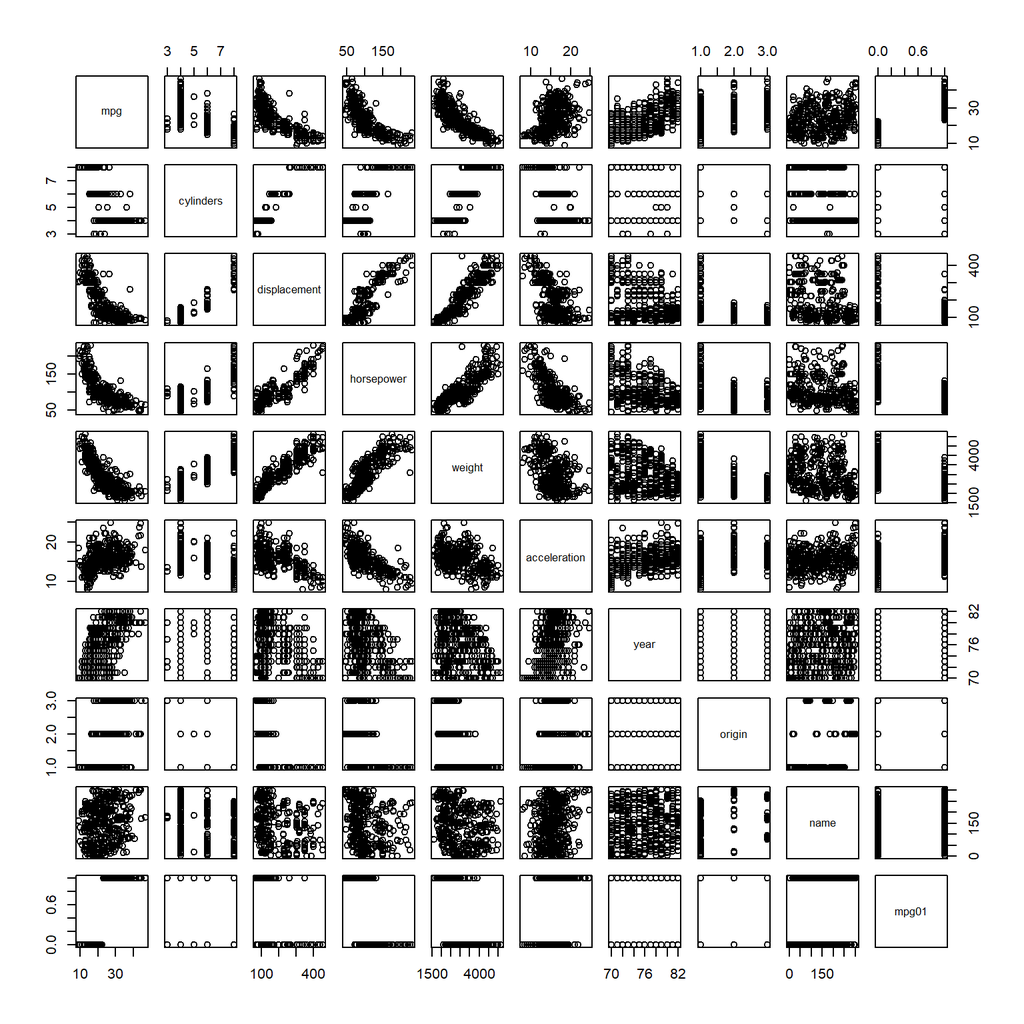

```r
pairs(new_Auto)
```

mpg weight horsepower acceleration displacement are most likely useful in predicting mpg01

#### (C)

```r
set.seed(1)
tr <- sample(1:nrow(new_Auto), nrow(new_Auto)*0.7 , replace=F)  # 70% train, 30% test
train <- new_Auto[tr,]
test <- new_Auto[-tr,]
```

#### (d)

```r
lda.fit=lda(mpg01~mpg+weight+horsepower+acceleration+displacement,train)
lda.pred=predict(lda.fit,test)
lda.class=lda.pred$class
table(lda.class,test$mpg01)
```

```
##
## lda.class  0  1
##         0 55  1
##         1  6 56
```

#### (e)

```r
qda.fit=qda(mpg01~mpg+weight+horsepower+acceleration+displacement,train)
qda.pred=predict(qda.fit,test)
qda.class=qda.pred$class
table(qda.class,test$mpg01)
```

```
##
## qda.class  0  1
##         0 55  2
##         1  6 55
```

```r
mean(qda.class==test$mpg01)
```

```
## [1] 0.9322034
```

#### (f)

```r
glm.fit=glm(mpg01~mpg+weight+horsepower+acceleration+displacement,train,family=binomial)
glm.prob=predict(glm.fit,test,type='response')
glm.pred=rep(0,93)
glm.pred[glm.prob>0.5]=1
table(glm.pred,test$mpg01)
```

[output not shown]

Test error rate is about 0

#### (g)

```r
library(class)
train.x=dplyr::select(train,mpg,weight,horsepower,acceleration,displacement)
train.y=dplyr::select(train,mpg01)[,1]
test.x=dplyr::select(test,mpg,weight,horsepower,acceleration,displacement)
test.y=dplyr::select(test,mpg01)[,1]
min_error_rate=1000
k=0
for (i in 1:200){
 knn.pred=knn(train.x,test.x,train.y,i)
 t=table(knn.pred,test$mpg01)
 error_rate=(t[2]+t[3])/sum(a)
 if(error_rate<min_error_rate){
   min_error_rate=error_rate
   k=i
 }
}
c(min_error_rate,k)
```

```
## [1] 1.5 3.0
```

```r
##There may be multiple functions with the same name in multiple packages. The double colon operator allows you to specify the specific function you want:
```

### Q12

#### (a)

```r
Power<-function(){
  print(2^3)
}
```

#### (b)

```r
Power2<-function(x,a){
  print(x^a)
}
Power2(3,8)
```

```
## [1] 6561
```

#### (c)

```r
a<-data.frame(c(3,8),c(8,17),c(131,3))
for(i in 1:3){
  Power2(a[1,i],a[2,i])
}
```

```
## [1] 6561
## [1] 2.2518e+15
## [1] 2248091
```

#### (d)

```r
Power3<-function(x,a){
  result=x^a
  return(result)
}
```

#### (e)

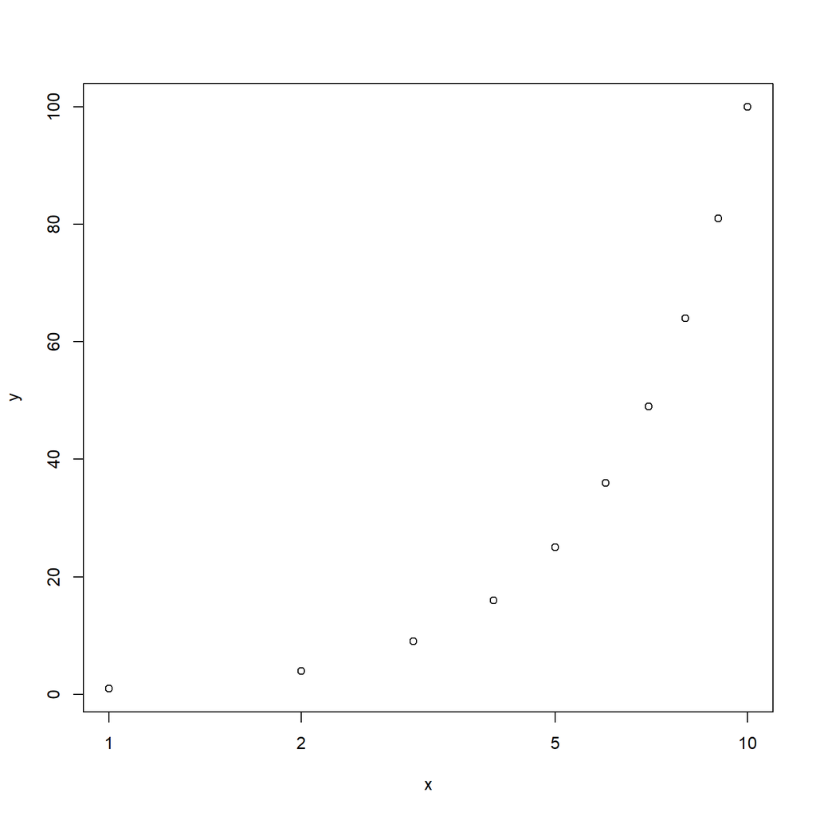

```r
x=1:10
y=rep(0,10)
for(i in 1:10){
  y[i]=Power3(i,2)
}
plot(x,y,log='x')
```

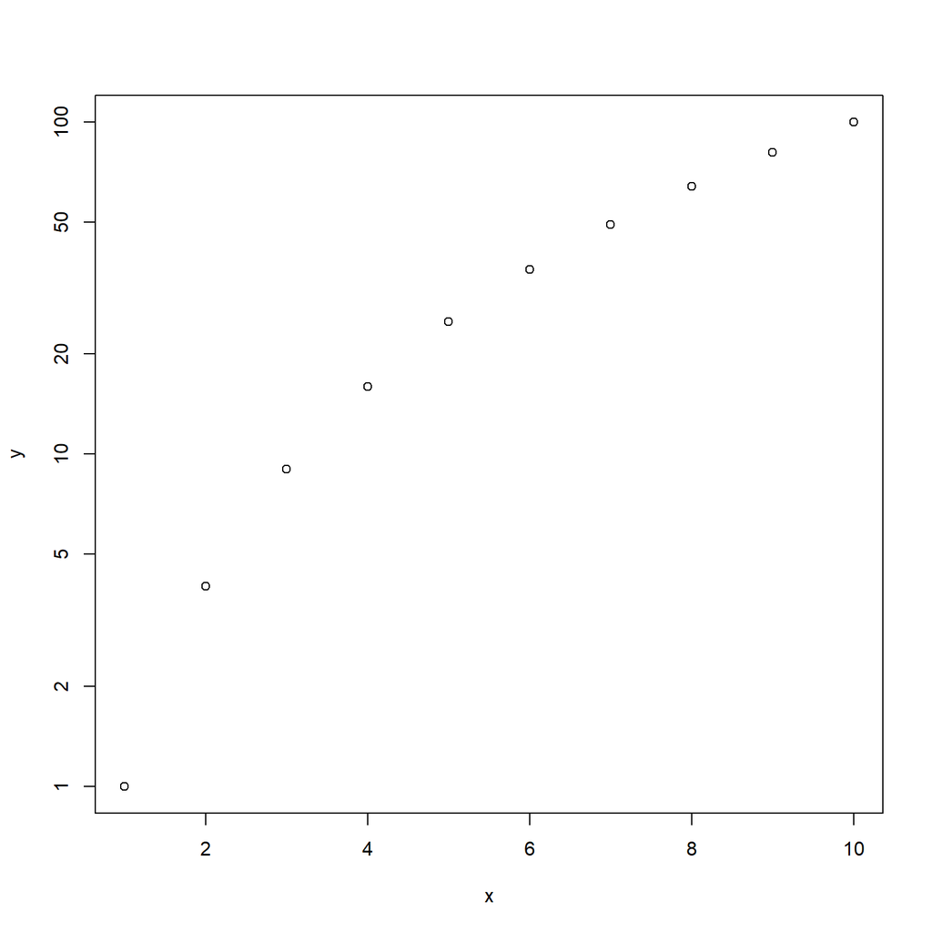

```r
plot(x,y,log='y')
```

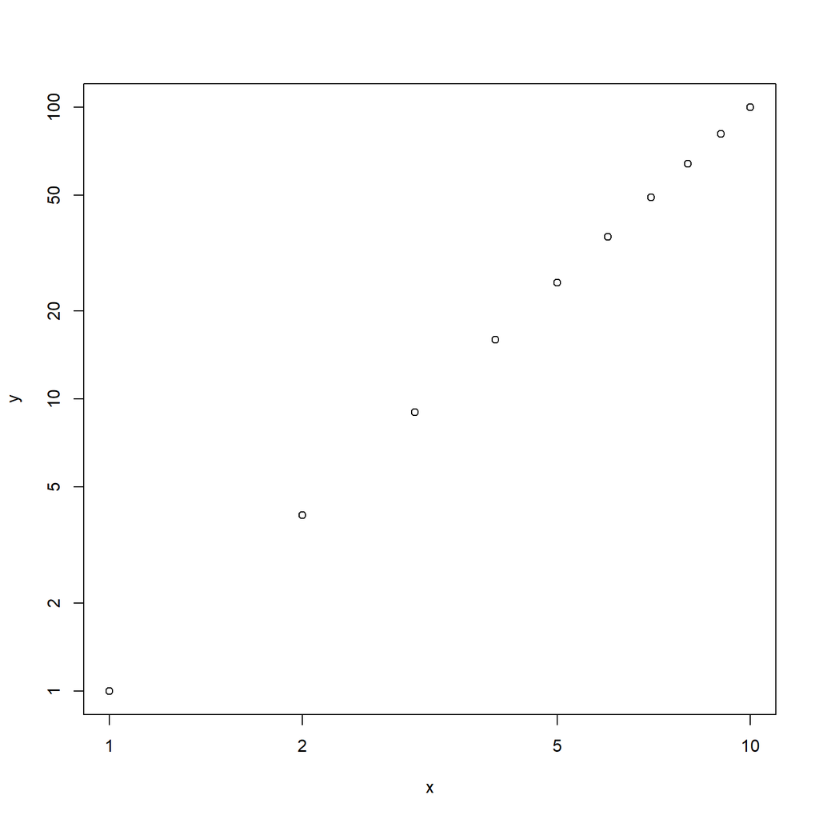

```r
plot(x,y,log='xy')
```

#### (f)

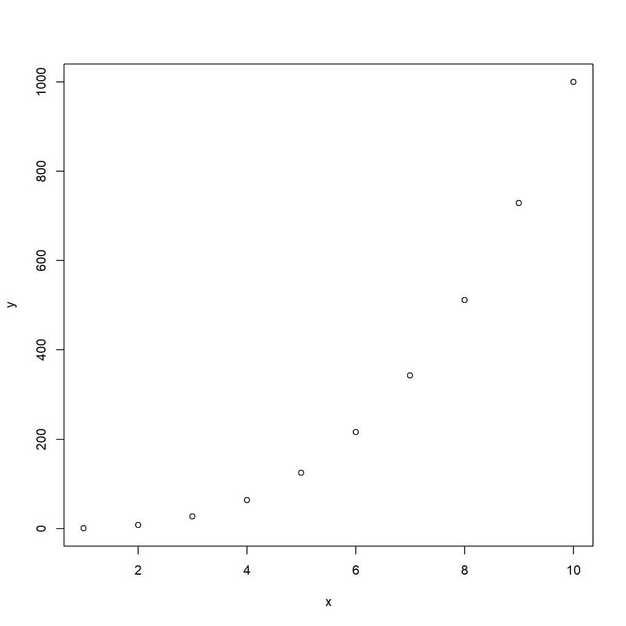

```r
PlotPower<-function(x,a){
  y=rep(0,length(x))
  for(i in 1:10){
    y[i]=Power3(x[i],a)
  }
  plot(x,y)
}
PlotPower(1:10,3)
```

### Q13